# Fragaceatoxin C

Fold-switch pair **4tsyD_3zwgN** — **4tsyD** vs **3zwgN**

Actinia fragacea

## Figure 1: Phylogenetic tree with per-cluster fold-preference heatmap.

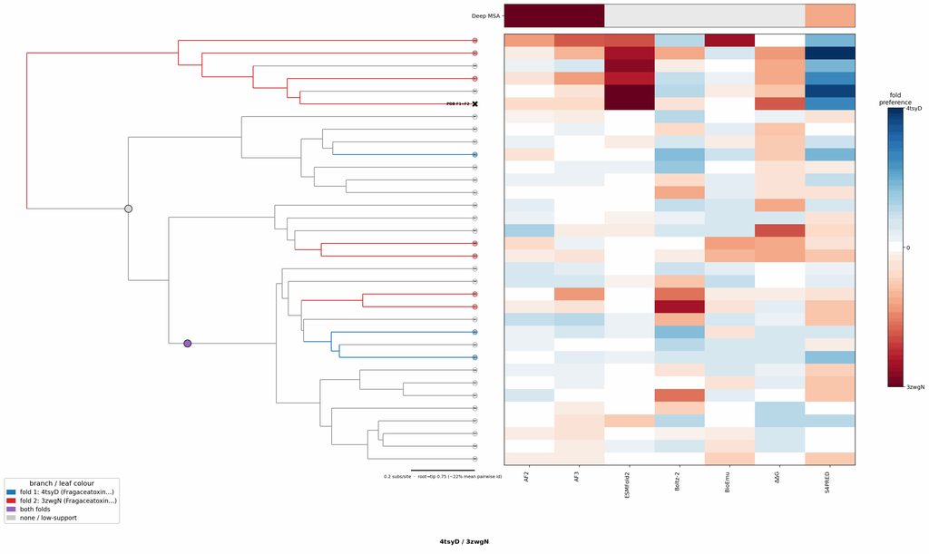

## Figure 2: Aligned overlay (both folds superposed)

The single fold-switching chain of each fold superposed by TM-align; waters hidden, any ligand shown as green sticks. Grey = structurally conserved core, colour = divergent (fold-switching) region.

4tsyD (Fragaceatoxin C)3zwgN (Fragaceatoxin C)Ligand HTO|HXJ (bound to 4tsyD)

TM-score: 0.851 · Trigger class: ligand

Aligned overlay

Loading...

## Figure 3: The two folds, side by side

Each fold is coloured by per-residue Cα deviation between the two superposed structures: grey ≈ conserved core, full colour = structurally divergent (fold-switching) region.

4tsyD (Fragaceatoxin C)

3zwgN (Fragaceatoxin C)

0 Å5≥10 Å

4tsyD (Fragaceatoxin C)

Loading...

3zwgN (Fragaceatoxin C)

Loading...

## Figure 4: Best-cluster predicted contact maps over the two true folds.

Predicted contact maps (MSA-Transformer) for the clusters best matching each fold, over the true contacts of fold 1 (upper triangle) and fold 2 (lower). Divergent contacts between clusters are the contact-level signature of fold-switching.

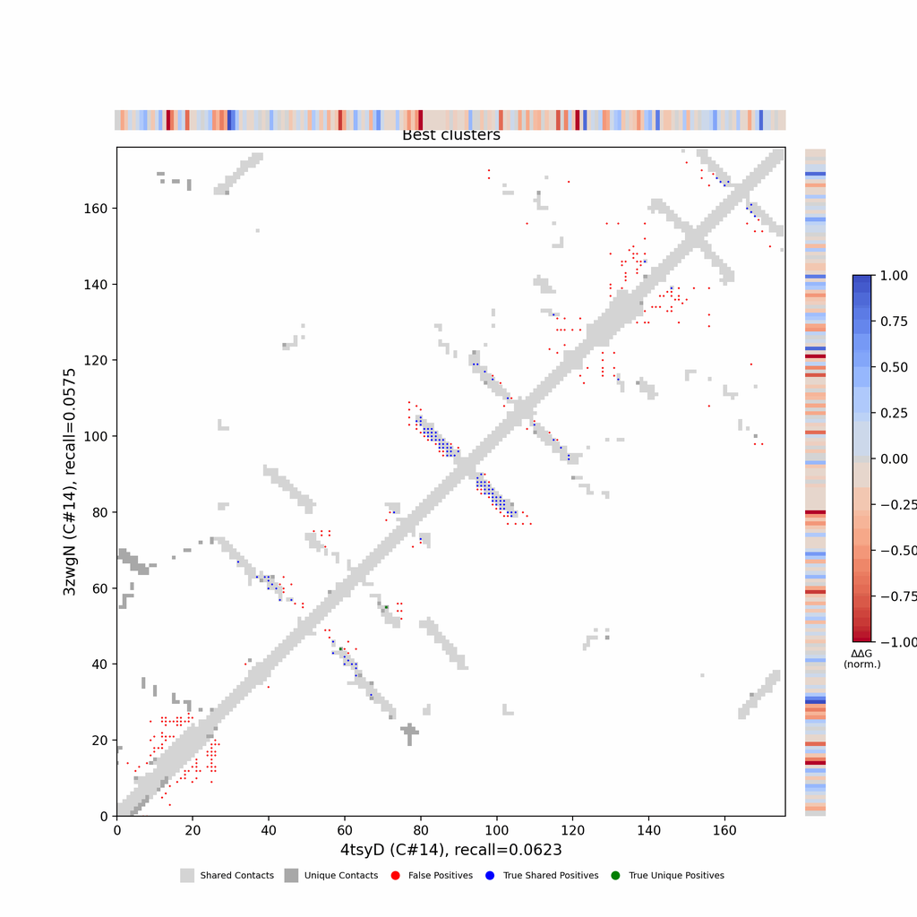

## Figure 5: Per-residue ΔΔG fold-preference contribution

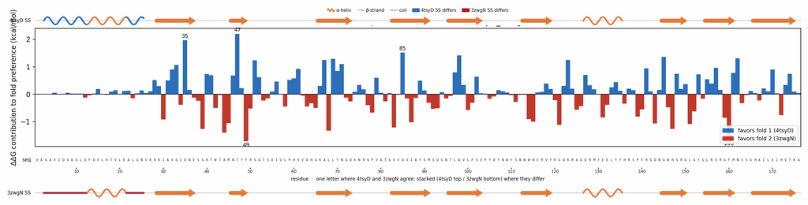

**More figures**

## Figure 6: Deep-MSA contact map panel / Best clusters contact map panel

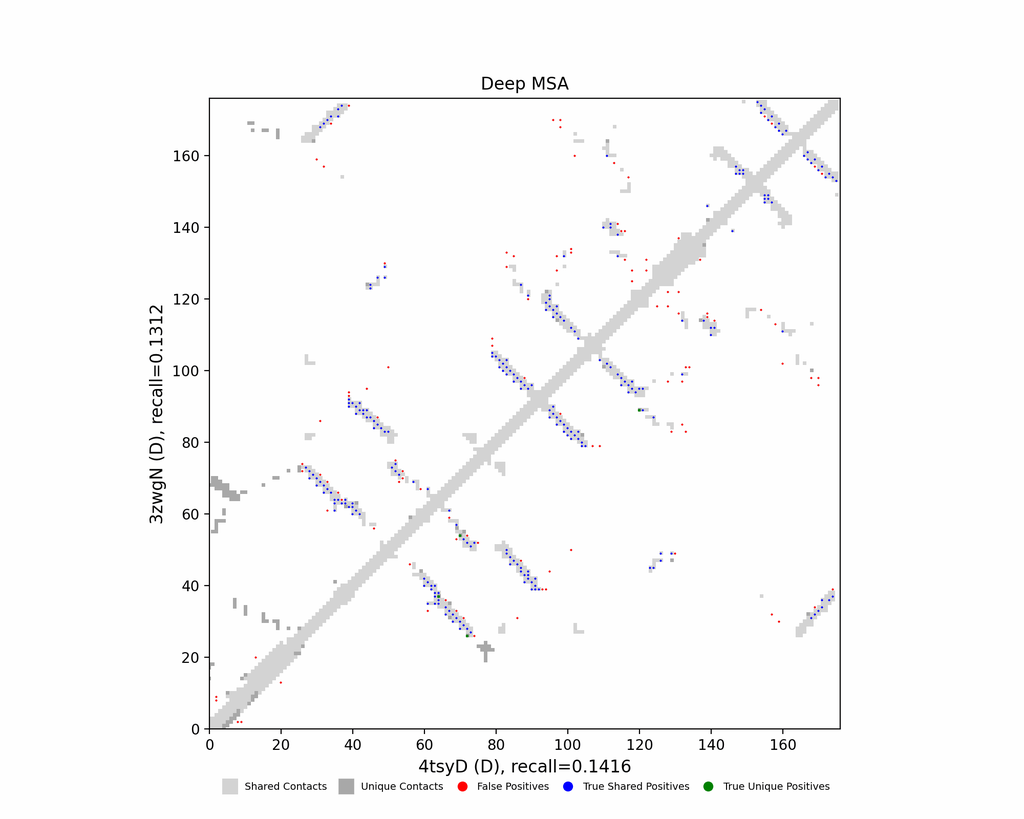

Deep-MSA contact map panel

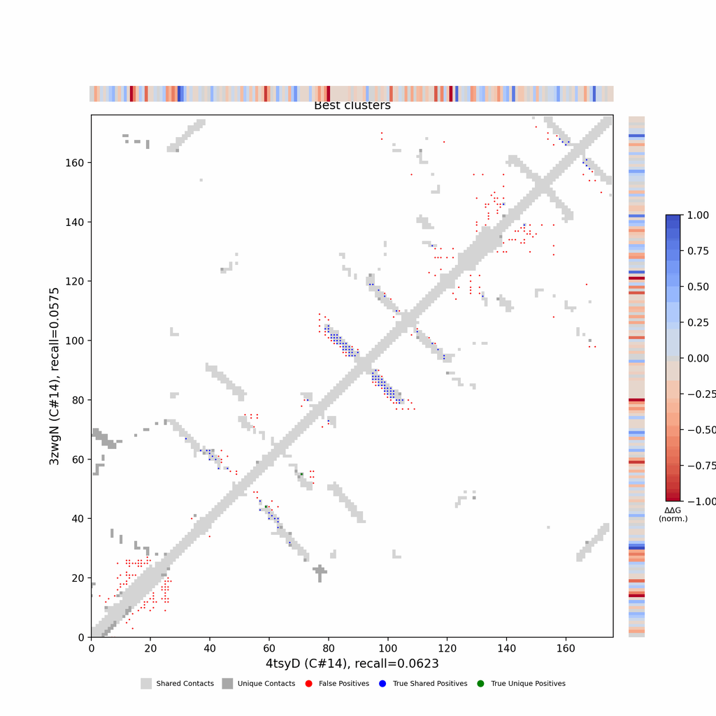

Best clusters contact map panel

## Figure 7: All clusters contact-map mosaic (small multiples).

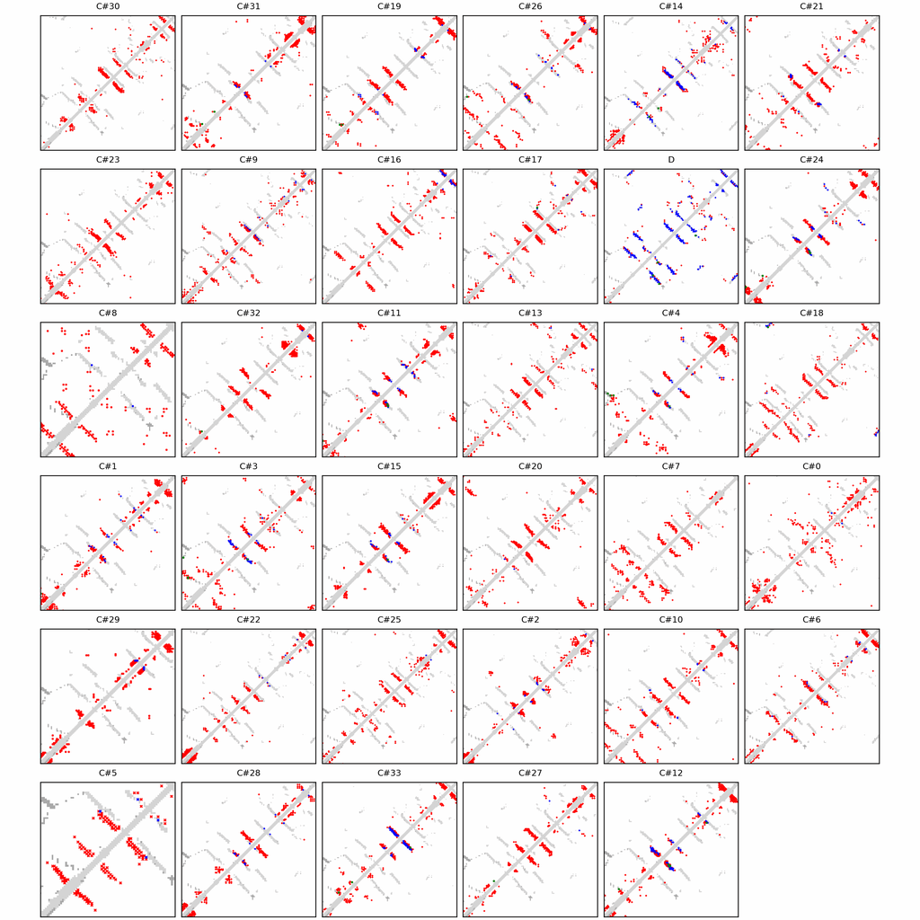

## Figure 8: Phylo null: tree with shuffled cluster fold labels.

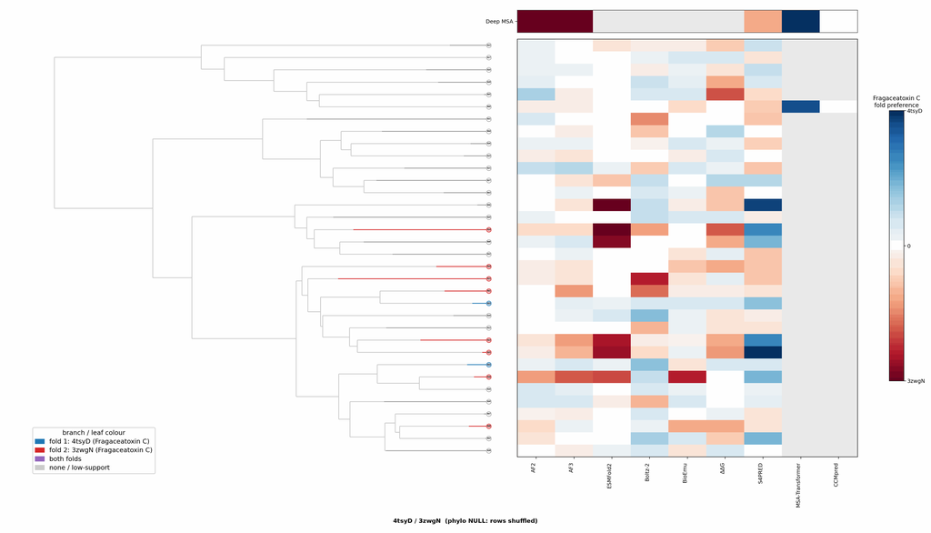

## Cluster metrics table

Per-cluster metrics underlying the figures above.

| cluster | n | neff | AF2_TM1 | AF2_TM2 | AF3_TM1 | AF3_TM2 | RE-MSAT-COM | RE-MSAT1 | RE-MSAT2 | ESM_SEQIDS | ESM_TM1 | ESM_TM2 | ΔΔG_Bias | ΔΔG_Bias_std | ΔΔG_frac_F1 | Boltz2_pref | S4PRED_pref | CCMpred_pref | BioEmu_pref |
| --- | --- | --- | --- | --- | --- | --- | --- | --- | --- | --- | --- | --- | --- | --- | --- | --- | --- | --- | --- |
| Deep | - | - | 0.85 | 0.98 | 0.85 | 0.99 | 0.43 | 0.42 | 0.38 | - | - | - | - | - | - | - | -0.02 | 0.0 | - |
| 000 | 88.0 | 5.0 | 0.44 | 0.45 | 0.36 | 0.37 | 0.0 | 0.0 | 0.0 | 001; 001; 009; 009; 007; 007; 002; 002; 003; 003 | 0.78 ± 0.04 | 0.84 ± 0.09 | 10.13 | 3.18 | 1.0 | -0.01 | -0.05 | 0.0 | -0.02 |
| 001 | 57.0 | 9.0 | 0.33 | 0.34 | 0.31 | 0.37 | 0.0 | 0.0 | 0.0 | - | - | - | 9.26 | 4.11 | 1.0 | -0.04 | -0.04 | - | -0.01 |
| 002 | 56.0 | 17.0 | 0.27 | 0.3 | 0.34 | 0.34 | 0.01 | 0.01 | 0.01 | - | - | - | 6.51 | 3.99 | 1.0 | 0.01 | -0.01 | - | 0.0 |
| 003 | 54.0 | 26.0 | 0.54 | 0.54 | 0.4 | 0.38 | 0.03 | 0.03 | 0.03 | - | - | - | 5.88 | 4.71 | 0.9 | -0.02 | -0.03 | - | -0.0 |
| 004 | 47.0 | 13.0 | 0.49 | 0.5 | 0.51 | 0.52 | 0.01 | 0.02 | 0.02 | - | - | - | 14.33 | 3.06 | 1.0 | -0.02 | -0.03 | - | -0.01 |
| 005 | 43.0 | 24.0 | 0.57 | 0.53 | 0.52 | 0.52 | 0.03 | 0.02 | 0.02 | - | - | - | 0.89 | 2.25 | 0.7 | 0.0 | -0.04 | - | 0.0 |
| 006 | 41.0 | 21.0 | 0.54 | 0.55 | 0.5 | 0.52 | 0.0 | 0.0 | 0.0 | - | - | - | 6.08 | 2.88 | 1.0 | 0.0 | 0.01 | - | -0.01 |
| 007 | 38.0 | 13.0 | 0.53 | 0.54 | 0.45 | 0.46 | 0.0 | 0.0 | 0.0 | - | - | - | 10.63 | 3.51 | 1.0 | 0.0 | -0.04 | - | -0.01 |
| 008 | 37.0 | 21.0 | 0.29 | 0.32 | 0.66 | 0.65 | 0.0 | 0.0 | 0.0 | - | - | - | 4.61 | 5.92 | 0.7 | -0.01 | -0.04 | - | -0.03 |
| 009 | 35.0 | 8.0 | 0.38 | 0.38 | 0.38 | 0.36 | 0.0 | 0.0 | 0.0 | - | - | - | 4.66 | 2.42 | 1.0 | -0.01 | -0.01 | - | -0.01 |
| 010 | 35.0 | 19.0 | 0.53 | 0.53 | 0.7 | 0.69 | 0.02 | 0.02 | 0.02 | - | - | - | 7.76 | 3.46 | 1.0 | -0.02 | -0.02 | - | -0.0 |
| 011 | 35.0 | 4.0 | 0.53 | 0.54 | 0.35 | 0.37 | 0.0 | 0.0 | 0.0 | - | - | - | 11.27 | 1.9 | 1.0 | -0.05 | -0.05 | - | -0.01 |
| 012 | 33.0 | 8.0 | 0.34 | 0.35 | 0.54 | 0.54 | 0.01 | 0.02 | 0.01 | - | - | - | 8.32 | 3.75 | 1.0 | -0.03 | -0.04 | - | -0.0 |
| 013 | 30.0 | 14.0 | 0.58 | 0.6 | 0.65 | 0.71 | 0.0 | 0.0 | 0.01 | - | - | - | 4.43 | 2.69 | 0.9 | 0.0 | -0.0 | - | -0.0 |
| 014 | 26.0 | 7.0 | 0.5 | 0.53 | 0.34 | 0.36 | 0.09 | 0.08 | 0.07 | - | - | - | 1.14 | 2.83 | 0.6 | -0.02 | -0.0 | - | -0.01 |
| 015 | 26.0 | 10.0 | 0.44 | 0.45 | 0.51 | 0.53 | 0.03 | 0.03 | 0.02 | - | - | - | 12.64 | 2.21 | 1.0 | -0.01 | -0.03 | - | -0.01 |
| 016 | 26.0 | 13.0 | 0.73 | 0.72 | 0.73 | 0.72 | 0.04 | 0.04 | 0.03 | - | - | - | 10.4 | 4.19 | 1.0 | 0.0 | -0.03 | - | -0.0 |
| 017 | 24.0 | 15.0 | 0.45 | 0.45 | 0.5 | 0.49 | 0.0 | 0.0 | 0.0 | - | - | - | 11.84 | 7.06 | 0.9 | -0.01 | -0.04 | - | 0.0 |
| 018 | 23.0 | 15.0 | 0.71 | 0.78 | 0.8 | 0.89 | 0.02 | 0.02 | 0.03 | - | - | - | 9.89 | 4.56 | 1.0 | 0.0 | -0.01 | - | -0.05 |
| 019 | 23.0 | 10.0 | 0.32 | 0.32 | 0.36 | 0.35 | 0.02 | 0.02 | 0.02 | - | - | - | 8.57 | 3.48 | 1.0 | 0.01 | -0.04 | - | -0.01 |
| 020 | 23.0 | 12.0 | 0.47 | 0.46 | 0.57 | 0.56 | 0.0 | 0.0 | 0.0 | - | - | - | 12.43 | 4.47 | 1.0 | 0.0 | -0.04 | - | 0.0 |
| 021 | 23.0 | 14.0 | 0.64 | 0.61 | 0.79 | 0.75 | 0.02 | 0.02 | 0.02 | - | - | - | 10.78 | 4.51 | 1.0 | -0.03 | -0.05 | - | 0.0 |
| 022 | 22.0 | 9.0 | 0.29 | 0.28 | 0.27 | 0.26 | 0.0 | 0.0 | 0.0 | - | - | - | 6.27 | 2.4 | 1.0 | -0.0 | -0.02 | - | -0.01 |
| 023 | 22.0 | 5.0 | 0.62 | 0.62 | 0.65 | 0.63 | 0.0 | 0.0 | 0.0 | - | - | - | 12.12 | 4.06 | 1.0 | -0.0 | -0.01 | - | 0.0 |
| 024 | 22.0 | 7.0 | 0.52 | 0.53 | 0.4 | 0.42 | 0.04 | 0.04 | 0.03 | - | - | - | 4.22 | 3.43 | 1.0 | -0.01 | -0.05 | - | -0.02 |
| 025 | 21.0 | 11.0 | 0.51 | 0.53 | 0.52 | 0.56 | 0.0 | 0.0 | 0.0 | - | - | - | 3.75 | 1.15 | 1.0 | -0.03 | 0.02 | - | 0.0 |
| 026 | 21.0 | 12.0 | 0.6 | 0.6 | 0.58 | 0.57 | 0.03 | 0.03 | 0.03 | - | - | - | 10.81 | 1.09 | 1.0 | -0.02 | -0.04 | - | 0.0 |
| 027 | 21.0 | 7.0 | 0.53 | 0.54 | 0.51 | 0.52 | 0.0 | 0.0 | 0.01 | - | - | - | 14.37 | 2.9 | 1.0 | 0.0 | -0.02 | - | -0.01 |
| 028 | - | - | 0.51 | 0.52 | 0.52 | 0.53 | 0.01 | 0.01 | 0.02 | - | - | - | 12.79 | 1.87 | 1.0 | 0.0 | -0.03 | - | -0.01 |
| 029 | 16.0 | 3.0 | 0.37 | 0.36 | 0.37 | 0.37 | 0.02 | 0.01 | 0.02 | - | - | - | 4.58 | 3.33 | 1.0 | 0.0 | -0.02 | - | 0.0 |
| 030 | 15.0 | 3.0 | 0.75 | 0.74 | 0.77 | 0.75 | 0.0 | 0.0 | 0.0 | - | - | - | 10.45 | 5.17 | 1.0 | -0.02 | -0.03 | - | 0.0 |
| 031 | 15.0 | 11.0 | 0.31 | 0.3 | 0.38 | 0.38 | 0.01 | 0.01 | 0.01 | - | - | - | 10.46 | 1.13 | 1.0 | -0.04 | -0.05 | - | -0.0 |
| 032 | 15.0 | 3.0 | 0.6 | 0.6 | 0.7 | 0.69 | 0.01 | 0.0 | 0.01 | - | - | - | 11.22 | 1.21 | 1.0 | -0.01 | -0.05 | - | -0.02 |
| 033 | 15.0 | 6.0 | 0.6 | 0.6 | 0.63 | 0.6 | 0.11 | 0.1 | 0.09 | - | - | - | 12.48 | 3.02 | 1.0 | 0.01 | -0.02 | - | -0.02 |